# Script 7: Instrumental Variables

Script 7 Spring 2025

# Recap

## The Problem of Unobservables

So far, we discussed randomised experiments, selection on observables, and started to look at more sophisticated identification in terms of difference-in-differences. But what about cases where we do not (cannot) observe covariates and do not have units that can serve as direct counterfactual? In such case, the *conditional independence assumption* does not hold. Take, for example, the following scenario: We would like to estimate the effect of *D* on *Y*, but are not able to observe the confounding variable *U*. Since *U* affects both the independent and dependent variable of interest, any naive estimate of the effect of *D* will be biased.

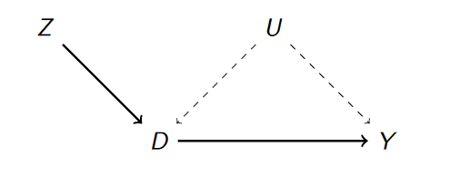

## Instrumental Variables

An instrumental variable (IV) design helps us circumvent this problem - as you have learned, though, a valif IV design rests on very strong assumptions that need to be met. If *D* is partly determined by *Z*, our instrument, we can estimate the effect of *D* on *Y*, **despite being unable to observe U.** To do so, *Z* must be determined as-if random and only affect *Y* through *D*, i.e. affect the outcome only through the treatment. Thus, we can take advantage of the variance randomly introduced by *Z*. In other words, IVs only allow us to estimate the effect for compliers - that is, those units whose *D* is affected by *Z*. The **local average treatment effect** - or **complier average causal effect** is then as follows:

$$LATE = \frac{E[Y_i|Z_i=1] -
E[Y_i|Z_i=0]}{E[D_i|Z_i=1] - E[D_i|Z_i=0]} = \frac{ITT_Y}{ITT_D}$$

## Two Stages Least Squares (2SLS)

In practice, IV designs are often estimated using 2SLS regressions. As opposed to manual calculations of the treatment effect, these estimators provide correct and robust measures of uncertainty and allow for the inclusion of covariates. The principle is simple: In the first stage, the treatment is regressed on the instrument and, possibly, covariates. The predicted values are then used in the second stage to fit the model. Importantly, both stages **always** need to include exactly the same covariates.

First Stage :
$$D_i = \alpha_1 + \phi Z_i
+ \beta_1 X_{1i} + \gamma_1 X_{2i} + e_{1i}$$

Second Stage:
$$Y_i = \alpha_2 +
\lambda \hat{D}_i + \beta_2 X_{1i} + \gamma_2 X_{2i} + e_{2i}$$

## IV Assumptions

For an IV design to be valid, several assumptions have to be met. In practice, this can be very hard to achieve. The five assumptions are:

1. **Monotonicity**: There are no defiers
2. **Exclusion Restriction**: The instrument affects the outcome **only** through the treatment
3. **Non-Zero Complier Proportion**: The instrument affects the treatment
4. **Random Assignment of Z**: The instrument is unrelated to potential outcomes
5. **SUTVA**

To satisfy these assumptions, usually good knowledge of context and the particular mechanisms is required. This is particularly the case for the *exclusion restriction*, which cannot be tested statistically. Accordingly, we must be able to make a convincing case for the assumption to hold. If there are good reasons to believe that the assumption does not hold, the IV design is likely invalid.

**Before starting this seminar**

1. Create a folder called “script7”
2. Download the data (you can use the button or the one at the top, or read csv files directly from github):
3. Open an R script (or Markdown file) and save it in our “script7” folder.
4. Set your working directory using the setwd() function or by clicking on “More“. For example *setwd(“~/Desktop/Causal Inference/2025/script7”)*
5. Let’s install an load packages that we will be using in this script:

```r
library(stargazer) # generate formated regression tables
library(texreg) # generate formatted regression tables
library(tidyverse) # to conduct some tidy operations
library(plm) # conduct one-way and two-way fixed effects
library(estimatr) #  to conduct ols and provides robust standard errors
library(lmtest) # calculates the variance-covariance matrix to be clustered by group.
library(multiwayvcov) # To cluster SEs
library(ivreg)
library(modelsummary)
library(fixest)
library(Hmisc) # for CI in ggplot figures
```

# Seminar Overview

In this **seminar**, we will cover the following topics:  
1. Manually estimate the treatment effect using an instrumental variable and the `lm()` function  
2. Run an IV regression using `ivreg()`, `iv_robust()` and `iv_feols()`  
3. Present the output of 2SLS regressions  
4. Manually calculate the *Wald estimator*  
5. Use Placebo tests to support the validity of the IV design.  
6. Check for weak instruments

## Does Choice Bring Loyalty?

Today will work with data from Elias Dinas’ work on [*Does Choice Bring Loyalty?*](https://onlinelibrary.wiley.com/doi/abs/10.1111/ajps.12044). In this paper, the author seeks to understand the foundation of partisan strength. There is a general debate over party identification (PID) in the literature. Some scholars claim that party identification strengthens with age. Others, including the author, suggest that voting for a party brings about loyalty and strengthens political attachment. A straightforward but naive empirical strategy would be to estimate the effect of having voted in one election on the strength of party identification a couple of years further down the line. However, both PID and vote choices are predicted by similar confounders - such research design would inevitably face the problem of unobserved covariates.

To address the research question without relying on such naive design, the author takes advantage of a comprehensive panel dataset. The original data include four waves - 1965/1973/1982/1997 -, of which the author uses two (1965 and 1973). In a smart move, Dinas then makes use of the timing of elections and the characteristics of participants in the panel: Elections took place in 1968 and in 1972. To be able to use the effect of voting, Dinas exploited the age of respondents. Importantly, respondents who were born in 1947 (76% of the sample) share a very important characteristic. What is it? They turned 21 - which was the voting age at the time - in 1968. Those who turned 21 before election day were able to vote in 1968, those who did not were only eligible to vote in 1972. This allows the author to exploit respondents’ birthdays - which are random at least in the short-term - to causally estimate the effect of voting on the strength of party identification. Obviously, however, not everyone who was eligible to vote in 1968 did vote.

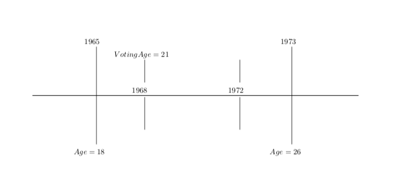

Besides various covariates, we will be using the following key variables:

| Variable | Description |
| --- | --- |
| `eligible68` | Dummy for eligibility to vote in 1968 election *(Instrument)*. |
| `voted68` | Dummy indicating whether participant voted in 1968 election *(Treatment)* |
| `strngpid73` | Strength of party identification in 1973 on an ordinal scale *(Outcome)* |
| `knowledge65` | Political knowledge in 1965 |
| `strngpid65` | Strength of party identification in 1965 |
| `elig2false` | Dummy variable for placebo tests: 0 for young eligible and 1 for old eligible participants |
| `v7` | Numerical code for school (which we’ll use for clustering SEs) |

Now let’s load the data. There are two ways to do this:

You can load the brands dataset from your laptop using the `read.csv()` function.

```r
# Set your working directory
#setwd("~/Desktop/Causal Inference/2025/script7")
#
library(haven)
#dinas <- read.csv("~/dinas.csv")
```

Or you can download the data from the course website from following url: https://bayreuth-politics.github.io/CI25/data/dinas.csv.

**Exercise 1: Use the `head()` function to familiarise yourself with the data set.**

**Reveal Answer**

```r
head(dinas)
```

[output not shown]

[output cut: 580 more lines]

This looks wild. The data set includes various variables which are not labeled really well. For now, let’s focus on the key variables presented above.

**Exercise 2: Regress the outcome (`strngpid73`) on the treatment (`voted68`) using `lm()`. Does the OLS provide a causal estimate?**

**Reveal Answer**

```r
ols <- lm(strngpid73 ~  voted68, data= dinas)
summary(ols)
```

```
Call:
lm(formula = strngpid73 ~ voted68, data = dinas)

Residuals:
    Min      1Q  Median      3Q     Max
-1.6187 -0.6187  0.3813  0.5741  1.5741

Coefficients:
            Estimate Std. Error t value Pr(>|t|)
(Intercept)  1.42593    0.04897  29.117  < 2e-16 ***
voted68      0.19276    0.06847   2.815  0.00499 **
---
Signif. codes:  0 '***' 0.001 '**' 0.01 '*' 0.05 '.' 0.1 ' ' 1

Residual standard error: 0.9521 on 772 degrees of freedom
  (16 observations deleted due to missingness)
Multiple R-squared:  0.01016,   Adjusted R-squared:  0.008881
F-statistic: 7.927 on 1 and 772 DF,  p-value: 0.004995
```

The naive OLS provides an estimate of `0.19`, which means that having voted in the 1968 election is associated with an increase of party identification of `0.19` on the PID scale. However, this does not provide a causal estimate: As we know, there are various factors that are likely to affect both the outcome and treatment. All we can say based on the OLS is the size of the bivariate correlation between these two variables.

Let’s also look at the visual relationship between these two variables:

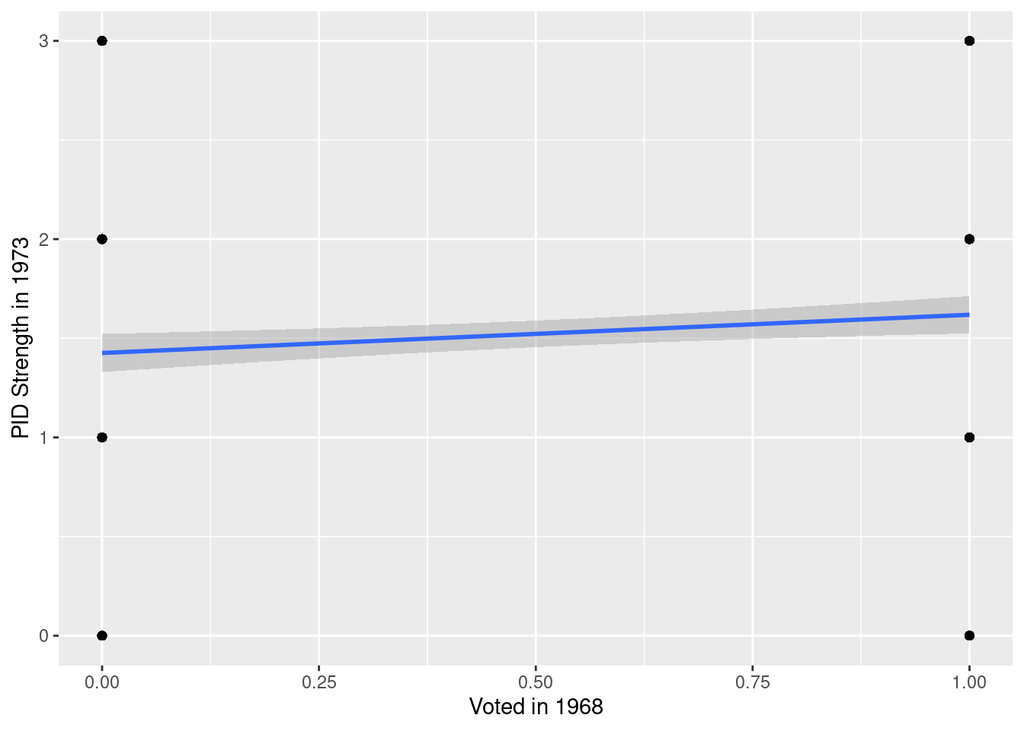

```r
# Using ggplot
ggplot(dinas, aes(x=voted68, y=strngpid73)) +
  geom_point()+
  geom_smooth(method=lm) +
  xlab("Voted in 1968") +
  ylab("PID Strength in 1973")
```

```r
# more sophisticated & appropriate figure -  give it a try!
#ggplot(subset(dinas, !is.na(voted68)), aes(x = factor(voted68), y = as.numeric(strngpid73))) +
#  stat_summary(fun = mean, geom = "point", color = "blue", size = 3, na.rm=T) +
#  stat_summary(fun.data = mean_cl_normal, geom = "errorbar", width = 0.2, color = "blue", na.rm=T) +
#  geom_jitter(width = 0.1, alpha = 0.1) +
#  xlab("Voted in 1968") +
#  ylab("PID Strength in 1973") +
#  theme_minimal()
```

Note that we are looking at an ordinal variable with discrete outcomes, where the fitted line indicates the average values for values on the x-axis. We can actually see a slight but significant increase in PID strength for those who voted in 1968. The decisive question is: can we causally say that having voted is the reason for this?

## IV Regression: 2SLS

We now know that a simple OLS doen’t provide any causal estimate. Let us now try to estimate the true treatment effect using an instrumental variable design. Following the author, we will be using the eligibility of respondents to vote in the 1968 election (`eligible68`) as instrument: That is, we exploit the randomness of respondents’ birthdays that determine their eligibility to vote in 1968. To do so, let’s separately look at the first and second stage.

**Exercise 3: Investigate the relationship between treatment (`voted68`) and instrument (`eligible68`)**

There are several ways to do this. Feel free to pick the option you deem most appropriate.

**Reveal Answer**

```r
table(dinas$eligible68, dinas$voted68)
```

```
      0   1
  0 132  25
  1 250 373
```

This looks ok. Of the 623 respondents who were eligible to vote in 1968, 373 did so. 250 decided not to vote. 25 respondents indicated that they voted although they were not eligible. How can that be? Most likely, they simply reported they voted even though they did not. They might have done so intentionally or misremembered the election - which might happen in such a long panel. It’s a bit annoying, but there’s not much we can do about it.

Let’s now calculate the first stage.

**Exercise 4: Regress the treatment on the instrument and extract the predicted values**

*Note: Make sure to add the argument `na.action=na.exclude` to your `lm()` function in order to deal with missing values. You can use `predicted_values <- predict(OLS_model)` to extract the predicted values.*

**Reveal Answer**

```r
# Calculating the first stage. Note `na.action=na.exclude` deals with NAs so we can use the predicted values for the second stage
first=lm(voted68~eligible68, data=dinas, na.action=na.exclude)

# Extracting predicted values
vote_pred=predict(first)

# Displaying regression output
summary(first)
```

```
Call:
lm(formula = voted68 ~ eligible68, data = dinas, na.action = na.exclude)

Residuals:
    Min      1Q  Median      3Q     Max
-0.5987 -0.5987  0.4013  0.4013  0.8408

Coefficients:
            Estimate Std. Error t value Pr(>|t|)
(Intercept)  0.15924    0.03738    4.26  2.3e-05 ***
eligible68   0.43948    0.04183   10.51  < 2e-16 ***
---
Signif. codes:  0 '***' 0.001 '**' 0.01 '*' 0.05 '.' 0.1 ' ' 1

Residual standard error: 0.4684 on 778 degrees of freedom
  (10 observations deleted due to missingness)
Multiple R-squared:  0.1243,    Adjusted R-squared:  0.1231
F-statistic: 110.4 on 1 and 778 DF,  p-value: < 2.2e-16
```

We can see that the instrument (`eligible68`) is indeed a strong and significant predictor of the treatment. That is what we expect and hope for. It’s also convincing to think that eligibility - i.e. respondents’ birthdays - is fully random.

Unfortunately, the first stage cannot tell you whether an instrument is appropriate. However, it can tell you something about inappropriate instruments. A common problem in IV designs are **weak instruments**. That is, if your instrument is only weakly correlated with the endogenous variable (i.e. the treatment), it is likely to render biased results - or ones that may not be really useful. The *F-Statistic* of the first stage can be used to identify weak instruments. The *F-Statistic* essentially tells us to what extent a model does a better job at explaining the outcome compared to the null model (here, that means comparing the bivariate model to only relying on the average of the outcome). As a rule of thumb, your instrument is likely to be problematic if the *F-Statistic* of your first stage regression is below 10.

Going back to the regression output, we see that our F-Statistic here is about `110` - so nowhere near the conventional threshold. Our instrument is strongly correlated with the treatment as it should be - but keep in mind that this does not necessarily mean that it is a valid instrument.

Let’s now proceed to test the exclusion restriction.

**Exercise 5: Test the exclusion restriction for the instrument.**

*Hint: Show that the instrument affects the outcome only through the treatment.*

**Reveal Answer**

If you have regressed the outcome on the instrument (and the treatment), this might help familiarise yourself with the data - but it does not provide a test of the *exclusion restriction*. In fact, it is impossible to statistically test the exclusion restriction. All we can do is rely on theory and build a convincing case for alternative effects not taking place. The problem with a regression of *Y* on *Z* (and *D*) is that we still cannot observe further confounders and account for their effects. We can’t know if their effect does not come into play in such a regression.

Let’s plot the relationship between the outcome and the instrument nonetheless. As stated above, we can’t tell whether the assumption holds, but we could at least get a better idea of the data.

**Exercise 6: Plot the relationship between the outcome and instrument.**

There are several ways to do this. Feel free to pick the option you deem most appropriate.

**Reveal Answer**

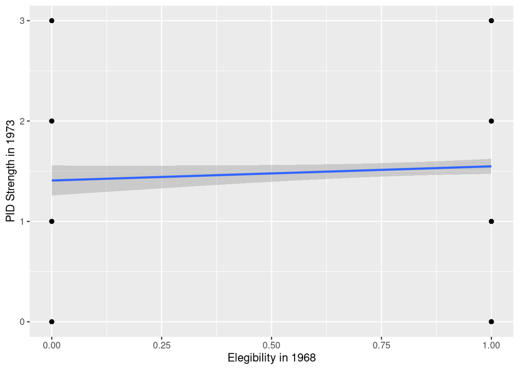

```r
# Using ggplot
ggplot(dinas, aes(x=eligible68, y=strngpid73)) +
  geom_point()+
  geom_smooth(method=lm) +
  xlab("Elegibility in 1968") +
  ylab("PID Strength in 1973")
```

```r
## more sophisticated & appropriate figure - give it a try!
#ggplot(dinas, aes(x = factor(eligible68), y = as.numeric(strngpid73))) +
#  stat_summary(fun = mean, geom = "point", color = "blue", size = 3, na.rm=T) +
#  stat_summary(fun.data = mean_cl_normal, geom = "errorbar", width = 0.2, color = "blue", na.rm=T) +
#  geom_jitter(width = 0.1, alpha = 0.1) +
#  xlab("Eligibility in 1968") +
#  ylab("PID Strength in 1973 (Ordinal)") +
#  theme_minimal()
```

This looks as expected. There is no clear and significant association between the two variables. Recall that eligibility itself should not affect party identification strength unless respondents have voted in 1968 as only voting should affect the outcome.

Let’s now return to our IV model by calculating the second stage of our 2SLS model.

**Exercise 7: Regress the outcome on the predicted values from the first stage**

**Reveal Answer**

```r
# Calculating the first stage
second_wrongSE=lm(strngpid73~vote_pred, data=dinas)

# Displaying regression output
summary(second_wrongSE)
```

```
Call:
lm(formula = strngpid73 ~ vote_pred, data = dinas)

Residuals:
    Min      1Q  Median      3Q     Max
-1.5525 -0.5525  0.4475  0.4475  1.5871

Coefficients:
            Estimate Std. Error t value Pr(>|t|)
(Intercept)   1.3623     0.1055  12.918   <2e-16 ***
vote_pred     0.3176     0.1952   1.627    0.104
---
Signif. codes:  0 '***' 0.001 '**' 0.01 '*' 0.05 '.' 0.1 ' ' 1

Residual standard error: 0.9554 on 772 degrees of freedom
  (16 observations deleted due to missingness)
Multiple R-squared:  0.003417,  Adjusted R-squared:  0.002126
F-statistic: 2.647 on 1 and 772 DF,  p-value: 0.1042
```

The second stage uses the predicted values for the treatment from the first stage. Calculating the second stage, the output indicates that - once we instrument for voting in 1968 - the decision to cast a vote in 1968 does not have a significant effect on party identification.

However, by calculating the two stages separately we have not adjusted standard errors and measures of uncertainty - R doesn’t know we were estimating a second stage at all. Accordingly, these measures will be biased and hypothesis testing is likely to provide false results - if we rely on such biased measures.

### IV Regression using 2SL2 in one step

Luckily, we can use 2SLS regressions to estimate both stages in a single step with adjusted standard errors and measures of uncertainty. There are several packages that we could use to retrieve a two-stage least squares instrumental variables estimator. Let’s now conduct 2SLS using the `ivreg()`, `iv_robust()`, `iv_feols()`.You can see the syntax for each of these functions below:

**Exercise 8: Conduct a two-stage least squares instrumental variable regression using `strngpid73` as the outcome, `voted68` as the endogenous predictor, and `eligible68` as the instrument. Use the `ivreg()` and `iv_robust()` functions. Store these models in a list (`list()`) and report them in a table. Interpret the results. In a next step, cluster the model’s standard errors by school (`v7`) using the functions you already know and the syntax below.**

| Variable | Description |
| --- | --- |
| `O` | Outcome variable |
| `E` | Endogenous variable (Treatment) |
| `I` | Instrument variable |
| `FE` | Fixed Effect variable (optional) |
| `cluster` | Specify cluster for SEs (optional) |

```r
ivreg(O ~ E | I, data = data ) # ivreg package

iv_robust(O ~ E | I, data = data, cluster =) # estimatr package

iv_feols(O  ~ E | FE | I, data = data) # fixest package
```

**Reveal Answer**

```r
## ivreg ##
ivreg_model <- ivreg(strngpid73 ~ voted68 | eligible68, data = dinas)

#This re-estimates the model and uses clustered SEs.
ivreg_model_clustered <- cluster.vcov(ivreg_model, dinas$v7)
iv_clustered <- coeftest(ivreg_model, ivreg_model_clustered)

## iv_robust ##
iv_robust_model <- iv_robust(strngpid73 ~ voted68 | eligible68, data = dinas)

# in iv_robust, we can directly cluster SEs within the function
iv_robust_model_cluster <- iv_robust(strngpid73 ~ voted68 | eligible68, data = dinas, cluster = v7)

ivmodels <- list(ivreg_model, iv_robust_model, iv_robust_model_cluster)
```

```r
rows <- tribble(~term,  ~ivreg_model, ~iv_robust_model, ~iv_robust_model_cluster,  'Covariates', 'No', 'No', 'No', 'Clustered SEs', 'No', 'No', 'School') # add one row reporting covariates
attr(rows, 'position') <- c(5,6)  ### Change location accordingly

title <- 'Two-stage Least Squares Models' # add the title to your model

coeffs <- c('(Intercept)'= 'Intercept',
                     'voted68' = 'Voted') # rename coefficients

# regression table
modelsummary(ivmodels,
             estimate = "{estimate}{stars}",
             coef_map = coeffs,
             gof_omit = 'DF|se_type',
             add_rows = rows,
             title = title)
```

|  | (1) | (2) | (3) |
| --- | --- | --- | --- |
| Intercept | 1.362*** | 1.362*** | 1.362*** |
|  | (0.106) | (0.103) | (0.095) |
| Voted | 0.319 | 0.319+ | 0.319+ |
|  | (0.196) | (0.192) | (0.175) |
| Covariates | No | No | No |
| Clustered SEs | No | No | School |
| Num.Obs. | 774 | 774 | 774 |
| R2 | 0.006 | 0.006 | 0.006 |
| R2 Adj. | 0.005 | 0.005 | 0.005 |
| AIC | 2128.0 | 2128.0 | 2128.0 |
| BIC | 2141.9 | 2141.9 | 2141.9 |
| RMSE | 0.95 | 0.95 | 0.95 |
| Std.Errors |  |  | by: v7 |

In 2SLS, we can further include covariates to estimate the covariate-adjusted LATE. Let’s try this and include some covariates in our 2SLS regressions. We can, in principle, also add additional instruments to our model - this is easily implemented as in the example below but be aware that you should be careful with this and be guided by theory when identifying instruments.

**Exercise 9: Use the `ivreg()` function and include the following covariates: `col1` and `col2`. Use the same endogenous treatment variable `voted68`. Include `eligible68` and `as.factor(knowledge1965)` as instruments. Report the results of this estimation using the `summary()` function. Include the arguments in the table below to the summary function. Report and interpret the F-Statistics for this specification. Are the instruments that we use strong or weak instruments?**

| Function/argument | Description |
| --- | --- |
| `Summary()` | Generic function to produce results summaries of model fitting functions |
| `diagnostics` | Set equal to TRUE it provides a number of diagnostic test. |

**Reveal Answer**

```r
ivreg_covariates <- ivreg(strngpid73 ~ col1 + col2 + voted68 |
             col1 + col2 + as.factor(knowledge65) + eligible68, data = dinas)

summary_ivreg <- summary(ivreg_covariates, diagnostics = TRUE)
summary_ivreg
```

```
Call:
ivreg(formula = strngpid73 ~ col1 + col2 + voted68 | col1 + col2 +
    as.factor(knowledge65) + eligible68, data = dinas)

Residuals:
    Min      1Q  Median      3Q     Max
-1.8142 -0.6389  0.1858  0.7256  1.8114

Coefficients:
            Estimate Std. Error t value Pr(>|t|)
(Intercept)  1.44974    0.09496  15.267   <2e-16 ***
col1        -0.26116    0.14418  -1.811   0.0705 .
col2        -0.17531    0.07732  -2.267   0.0236 *
voted68      0.36445    0.18310   1.990   0.0469 *

Diagnostic tests:
                 df1 df2 statistic p-value
Weak instruments   8 763    15.967  <2e-16 ***
Wu-Hausman         1 769     0.816   0.367
Sargan             7  NA     4.225   0.754
---
Signif. codes:  0 '***' 0.001 '**' 0.01 '*' 0.05 '.' 0.1 ' ' 1

Residual standard error: 0.9527 on 770 degrees of freedom
Multiple R-Squared: 0.0115, Adjusted R-squared: 0.007647
Wald test:  2.81 on 3 and 770 DF,  p-value: 0.03861
```

```r
# Add clustered robust standard errors
ivreg_covariates_clustered <- cluster.vcov(ivreg_covariates, dinas$v7)
coeftest(ivreg_covariates, ivreg_covariates_clustered)
```

```
t test of coefficients:

             Estimate Std. Error t value Pr(>|t|)
(Intercept)  1.449743   0.083194 17.4260  < 2e-16 ***
col1        -0.261162   0.124099 -2.1045  0.03566 *
col2        -0.175310   0.073302 -2.3916  0.01701 *
voted68      0.364451   0.158050  2.3059  0.02138 *
---
Signif. codes:  0 '***' 0.001 '**' 0.01 '*' 0.05 '.' 0.1 ' ' 1
```

Based on the modified specification, we observe that voting in 1968 had a positive and statistically significant effect on partisanship strength down the line. Also, we see the output of several diagnostic tests generated once we set the `diagnostics` argument to `TRUE`. Let’s look at what they tell us in turn.

The weak instruments test shows to what extent the instrument has a low correlation with the endogenous explanatory variable - which would be problematic for the IV design. This is, in principle, the same aspect we tested using the F-test as a rule of thumb earlier. The null hypothesis is that the instrument insufficiently predicts treatment - which can be rejected in this case.

The Wu-Hausman test performs an efficiency test that reports whether the IV estimation is just as consistent as OLS. The null hypothesis is that OLS estimates are consistent. In this case, we do not reject the null hypothesis. Therefore, we claim that our IV model is as good as OLS - and the latter being preferable as it is more efficient. Note that this is a purely statistical test, however, and while indicative should not overrule theoretical concerns. In any case, you should estimate your IV model - if OLS is consistent, it is simply somewhat more efficient.

Besides 2SLS, we can also obtain the Local Average Treatment Effect (LATE) by computing the difference of the conditional expectations of the outcome on the instrument (reduced form) divided by the difference of the conditional expectations of the treatment take-up on the instrument (first stage). Put simply, this corresponds to calculating the difference in the means of the outcome between units assigned to the treatment minus those units not assigned to the treatment. Then, we divide this number by the difference in the share of received treatment in those two groups (i.e. compliance rates).

| Variable/Average | Description |
| --- | --- |
| `Y` | Outcome |
| `Z` | Instrument |
| `D` | Endogenous treatment |
| `Y[Z=1]` | Average outcome conditional for units offered the treatment |
| `Y[Z=0]` | Average outcome conditional for units not offered the treatment |
| `D[Z=1]` | Proportion of units receiving the treatment for those assigned to the treatment |
| `D[Z=0]` | Proportion of units receiving the treatment for those not assigned to the treatment |

The Wald Estimator is then:

$$\tau=\frac{Y[Z=1]-Y[Z=0]}{D[Z=1]-D[Z=0]}$$

**Exercise 10: Manually calculate the Wald Estimator. Use the `mean(x, na.rm = T)` function to calculate the means of each group. You can use the following syntax to obtain the conditional means.**

```r
mean(data$outcome[data$instrument == 1], na.rm = TRUE) # 1 for those that were eligible, 0 for those that were not eligible.

mean(data$endongeous_variable[data$instrument == 1], na.rm = TRUE)  # 1 for those that were eligible, 0 for those that were not eligible.
```

**Reveal Answer**

```r
#Numerator
mean(dinas$strngpid73[dinas$eligible68==1], na.rm=T)
```

```
[1] 1.5488
```

```r
mean(dinas$strngpid73[dinas$eligible68==0], na.rm=T)
```

```
[1] 1.407643
```

```r
#Denominator
mean(dinas$voted68[dinas$eligible68==1], na.rm=T)
```

```
[1] 0.5987159
```

```r
mean(dinas$voted68[dinas$eligible68==0], na.rm=T)
```

```
[1] 0.1592357
```

Then, $\tau=$ is equal to:

```r
(mean(dinas$strngpid73[dinas$eligible68==1], na.rm=T) - mean(dinas$strngpid73[dinas$eligible68==0], na.rm=T)) / (mean(dinas$voted68[dinas$eligible68==1], na.rm=T) - mean(dinas$voted68[dinas$eligible68==0], na.rm=T))
```

```
[1] 0.3211901
```

We see that the estimate of the Wald estimator is 0.32, which is pretty close to the estimate obtained from the `ivreg()` function.

How would you compute the Wald estimator for a binary endogenous variable and a binary instrument, but including covariates - or, similarly, for non-binary instruments or endogenous variables?

**Reveal Hint 1**

Remember that the beta coefficient of your variable of interest (let’s call it $X_{1i}$) in a bivariate regression is equal to:

$$\beta_1 = \frac{Cov(Y_i,
X_{1i})}{V(X_{1i})}$$

**Reveal Hint 2**

Similarly, the 2SLS estimator simply is the ratio of the reduced form divided by the first stage. Note that the variances of $Z$ are the same, thus they cancel out. Thus, we get the equivalent of th Wald estimator by using the covariances. This allows us to estimate the LATE for non-binary instruments and treatments.

$$\lambda_{\text{2SLS}} = \frac{Cov(Y_i,
Z_i)}{Cov(D_i, Z_i)}$$

So far so good. Now, if we want to account for covariates, we need to get rid of the variation they explain. To do this, we essentially need to regress the outcome, the treatment, and the instrument **each** and the vector of covariates. And it has to be the full and *same* vector of covariates for all equations - sounds familiar? Once we’ve done this, we take the residuals from each regression (e.g, $\tilde{Y_i}$, $\tilde{D_i}$, and $\tilde{Z_i}$), which gives us the remaining covariances after excluding the effect of covariates, and use the same logic as above:

$$\lambda_{\text{2SLS}} =
\frac{\text{Cov}(\tilde{Y_i}, \tilde{Z_i})}{\text{Cov}(\tilde{D_i},
\tilde{Z_i})}$$

In our case of no covariates, we can use the `cov()` function. You can see the arguments of this function below:

| Function/argument | Description |
| --- | --- |
| `cov(x, y)` | Function that calculates the covariance between two variables `x` and `y` |
| `use` | Argument indicating how missing values should be treated |
| `pairwise.complete.obs` | Uses all observations that have non-missing values for the indicated variables. More details below. |

Setting the `use` argument equal to *pairwise.complete.obs* computes the mean and covariance of `x` and `y` using all observations, where neither variable has missing values.

```r
tau_cov =cov(dinas$eligible68,dinas$strngpid73, use = "pairwise.complete.obs")/
  cov(dinas$eligible68,dinas$voted68, use = "pairwise.complete.obs")
tau_cov
```

```
[1] 0.3205741
```

**Keep in mind that using IV we can ‘only’ estimate the Local Average Treatment Effect (LATE). This means that we are estimating the causal effect for one particular group of treated units, which are the compliers.**

**Exercise 11: Calculate the proportions of compliers, defiers, always-takers, and never takers. Before you do so, attach labels to the instrument and treatment variables, so we can easily identify each group. You can use the `factor()` function. You can see a description of the syntax below. Assign the following labels to the `eligible68` variable: “Not eligible” and “Eligible”. For the `voted68` variable assign the labels “Not voted”, “Voted”. Lastly: why do we actually impose the monotonicity assumption on IV designs?***

| Function/argument | Description |
| --- | --- |
| `factor` | To encode a vector as a factor |
| `levels` | An optional vector of the unique values |
| `labels` | An optional character vector of labels for the levels |

```r
data$variable = factor(data$variable, levels = c(1, 2, 3,..,5),
                       labels = c("One", "Two", "Three"..."Five"))
```

**Reveal Answer**

```r
dinas$eligible68n=factor(dinas$eligible68,
                        levels=c(0,1),
                        labels=c( "Not Eligible", "Eligible"))
dinas$voted68n=factor(dinas$voted68,
                     levels=c(0,1),
                     labels=c("Not Voted","Voted"))


table(dinas$eligible68n, dinas$voted68n)
```

```
               Not Voted Voted
  Not Eligible       132    25
  Eligible           250   373
```

From the table above, we can see that the number of respondents that were not eligible and didn’t vote is 132, this group is composed of never-takers and compliers. The 25 subjects are respondents that were not eligible and voted anyway. This group is comprised of always takers and defiers. The 250 are respondents that were eligible but didn’t vote nonetheless. This group is composed of never takers, plus defiers. Finally, we have 373 respondents that were eligible and indeed voted. This group is composed of always takers and compliers.

By imposing the monotonicity assumption, we rule out the existence of defiers. Under the assumption of random assignment of the instrument, we further expect the share of compliance types to be - in expectation - equivalent in the group assigned to treatment and those assigned to control. This means that the 25 respondents that were **not** eligible to vote and voted anyway are indeed always takers (25/157=*0.16*), indicating `16%` of each group are always-takers. Similarly, there are 250 respondents in the group assigned to treatment who are never-takers (250/(373+250) = *0.40*), giving us a share of `40%` never-takers.

Finally, we can estimate the proportion of compliers in either group. In the control group, we know it must be `44%` (1 minus the share of always-takers and never-takers: 1-0.16-0.40), with the same logic also applying to the treatment group (1-0.4-0.16=`0.44`).

Luckily, we don’t have to calculate the share of each compliance type if we impose our assumptions. If you remember from the Wald estimator, the proportion of compliers (in the denominator) was `0.44`, which also is equivalent to the difference between those assigned to treatment who received treatment (`0.6` = 1-NT) and those who received treatment in the control group (`0.16` = AT).

**Exercise 12: Conduct a placebo test. Use the `ivreg()` function and as the main outcomes the partisan strength measured in 1973, `strngpid73`, as well as in 1965, `strngpid65`. Use `elig2false` as the placebo treatment variable. Remember to cluster the standard errors. What’s your interpretation of the findings?**

**Reveal Answer**

```r
plac <- lm(strngpid73 ~ elig2false, data=dinas)
# Cluster standard errors
plac.vcovCL <- cluster.vcov(plac, dinas$v7)
coeftest(plac, plac.vcovCL)
```

```
t test of coefficients:

             Estimate Std. Error t value Pr(>|t|)
(Intercept)  1.571111   0.046317 33.9208   <2e-16 ***
elig2false  -0.079683   0.085554 -0.9314    0.352
---
Signif. codes:  0 '***' 0.001 '**' 0.01 '*' 0.05 '.' 0.1 ' ' 1
```

```r
plac2 <- lm(strngpid65 ~ eligible68, data=dinas)
plac2.vcovCL <- cluster.vcov(plac2, dinas$v7)
coeftest(plac2, plac2.vcovCL)
```

```
t test of coefficients:

             Estimate Std. Error t value Pr(>|t|)
(Intercept)  1.782609   0.067535 26.3953   <2e-16 ***
eligible68  -0.025852   0.081025 -0.3191   0.7498
---
Signif. codes:  0 '***' 0.001 '**' 0.01 '*' 0.05 '.' 0.1 ' ' 1
```

```r
# We can also test ivreg - but should expect a weak instrument

ivreg_plac <- ivreg(strngpid73 ~ voted68 | elig2false, data = dinas)

summary(ivreg_plac, diagnostics = TRUE)
```

```
Call:
ivreg(formula = strngpid73 ~ voted68 | elig2false, data = dinas)

Residuals:
    Min      1Q  Median      3Q     Max
-10.079  -8.079   5.147   6.147   7.147

Coefficients:
            Estimate Std. Error t value Pr(>|t|)
(Intercept)    10.08      67.24   0.150    0.881
voted68       -14.23     112.19  -0.127    0.899

Diagnostic tests:
                 df1 df2 statistic p-value
Weak instruments   1 617     0.017   0.897
Wu-Hausman         1 616     0.919   0.338
Sargan             0  NA        NA      NA

Residual standard error: 7.147 on 617 degrees of freedom
Multiple R-Squared: -53.99, Adjusted R-squared: -54.08
Wald test: 0.01608 on 1 and 617 DF,  p-value: 0.8991
```

We see that there is no statistically significant difference between young and old eligible voters. Thus, this suggests that age does not drive the differences in partisanship strength we unravelled earlier - and we get more confident about the proposed mechanism of actually voting for a party.

**Exercise 13: Try to think of possible ways of how the exclusion restriction could be violated in this setting. Through what paths could the instrument affect the outcome, apart from the endogenous treatment?**

# Questions

1. Should you include all non-endogenous covariates in the first state? Why or why not?
2. What is the main identification assumption of instrumental variable estimations? How can you test it?
3. Can you use more than one instrument (exogenous variables, i.e. multiple `Z`s) for one treatment (endogenous variable, `D`)?
4. What’s the difference between the ITT and LATE from IV? Discuss with reference to compliers.
5. What’s the forbidden regression? Why is it forbidden?